# Introduction

In this notebook we'll learn how to use NumPy to work with numerical data.

[figure not shown]

# Import Statements

```python
import numpy as np

import matplotlib.pyplot as plt
from scipy import misc # contains an image of a racoon!
from PIL import Image # for reading image files
```

# Understanding NumPy's ndarray

NumPy's most amazing feature is the **powerful** ndarray.

[figure not shown]

#### 1-Dimensional Arrays (Vectors)

```python
my_array = np.array([1.1, 9.2, 8.1, 4.7])
```

```python
my_array.shape
```

```
(4,)
```

```python
my_array[2]
```

```
8.1
```

```python
my_array.ndim
```

```
1
```

#### 2-Dimensional Arrays (Matrices)

```python
array_2d = np.array([[1, 2, 3, 9],
                     [5, 6, 7, 8]])
```

```python
print(f'array_2d has {array_2d.ndim} dimensions')
print(f'Its shape is {array_2d.shape}')
print(f'It has {array_2d.shape[0]} rows and {array_2d.shape[1]} columns')
print(array_2d)
```

```
array_2d has 2 dimensions
Its shape is (2, 4)
It has 2 rows and 4 columns
[[1 2 3 9]
 [5 6 7 8]]
```

```python
array_2d[1,2]
```

```
7
```

```python
array_2d[0,:]
```

```
array([1, 2, 3, 9])
```

#### N-Dimensional Arrays (Tensors)

**Challenge**:

- How many dimensions does the array below have?
- What is its shape (i.e., how many elements are along each axis)?
- Try to access the value `18` in the last line of code.
- Try to retrieve a 1 dimensional vector with the values `[97, 0, 27, 18]`
- Try to retrieve a (3,2) matrix with the values `[[ 0, 4], [ 7, 5], [ 5, 97]]`

*Hint*: You can use the `:` operator just as with Python Lists.

```python
mystery_array = np.array([[[0, 1, 2, 3],
                           [4, 5, 6, 7]],

                         [[7, 86, 6, 98],
                          [5, 1, 0, 4]],

                          [[5, 36, 32, 48],
                           [97, 0, 27, 18]]])

# Note all the square brackets!
```

```python
mystery_array.ndim
```

```
3
```

```python
mystery_array.shape
```

```
(3, 2, 4)
```

```python
mystery_array[2,1,3]
```

```
18
```

```python
mystery_array[2,1]
```

```
array([97,  0, 27, 18])
```

```python
mystery_array[:,:,0]
```

```
array([[ 0,  4],
       [ 7,  5],
       [ 5, 97]])
```

# NumPy Mini-Challenges

#### **Challenge 1**: Use [`.arange()`](https://numpy.org/devdocs/reference/generated/numpy.arange.html)to createa a vector `a` with values ranging from 10 to 29. You should get this:

`print(a)`

`[10 11 12 13 14 15 16 17 18 19 20 21 22 23 24 25 26 27 28 29]`

```python
a = np.arange(10,30)
print(a)
```

```
[10 11 12 13 14 15 16 17 18 19 20 21 22 23 24 25 26 27 28 29]
```

```python
a[-3::]
```

```
array([27, 28, 29])
```

```python
a[4:7]
```

```
array([14, 15, 16])
```

```python
a[12::]
```

```
array([22, 23, 24, 25, 26, 27, 28, 29])
```

#### **Challenge 3**:Reverse the order of the values in `a`, so that the first element comes last:

```
[29, 28, 27, 26, 25, 24, 23, 22, 21, 20, 19, 18, 17, 16, 15, 14, 13,
       12, 11, 10]
```

If you need a hint, you can check out this part of the [NumPy beginner's guide](https://numpy.org/devdocs/user/absolute_beginners.html#how-to-reverse-an-array)

```python
np.flip(a)
```

```
array([29, 28, 27, 26, 25, 24, 23, 22, 21, 20, 19, 18, 17, 16, 15, 14, 13,
       12, 11, 10])
```

#### **Challenge 4**: Print out all the indices of the non-zero elements in this array: [6,0,9,0,0,5,0]

```python
b=np.array([6,0,9,0,0,5,0])
```

```python
nz_indices = np.nonzero(b)
```

```python
nz_indices
```

```
(array([0, 2, 5], dtype=int64),)
```

#### **Challenge 5**: Use NumPy to generate a 3x3x3 array with random numbers

Hint: Use the [`.random()` function](https://numpy.org/doc/stable/reference/random/index.html?highlight=random#module-numpy.random)

```python
from numpy.random import random
z = random((3,3,3))
z
```

```
array([[[0.7531849 , 0.66792086, 0.64490907],
        [0.95650796, 0.69800546, 0.78222013],
        [0.65712846, 0.66336391, 0.35372686]],

       [[0.83784316, 0.80556289, 0.49040456],
        [0.22611192, 0.03849964, 0.97882286],
        [0.52243447, 0.09119661, 0.70581112]],

       [[0.80729035, 0.20652218, 0.88718103],
        [0.86668903, 0.88620364, 0.84111275],
        [0.09414432, 0.66853969, 0.01960596]]])
```

#### **Challenge 6**: Use [`.linspace()`](https://numpy.org/doc/stable/reference/generated/numpy.linspace.html) to create a vector `x` of size 9 with values spaced out evenly between 0 to 100 (both included).

```python
x = np.linspace(0,100,num=9)
x
```

```
array([  0. ,  12.5,  25. ,  37.5,  50. ,  62.5,  75. ,  87.5, 100. ])
```

#### **Challenge 7**: Use [`.linspace()`](https://numpy.org/doc/stable/reference/generated/numpy.linspace.html) to create another vector `y` of size 9 with values between -3 to 3 (both included). Then plot `x` and `y` on a line chart using Matplotlib.

```python
y = np.linspace(-3,3,num=9)
y
```

```
array([-3.  , -2.25, -1.5 , -0.75,  0.  ,  0.75,  1.5 ,  2.25,  3.  ])
```

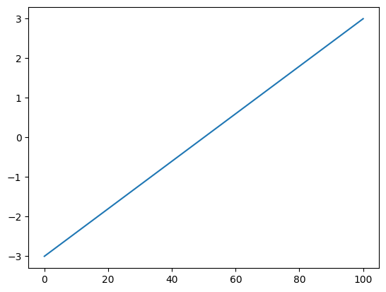

```python
plt.plot(x,y)
plt.show()
```

#### **Challenge 8**: Use NumPy to generate an array called `noise` with shape 128x128x3 that has random values. Then use Matplotlib's [`.imshow()`](https://matplotlib.org/3.1.1/api/_as_gen/matplotlib.pyplot.imshow.html) to display the array as an image.

```
(128, 128, 3)
```

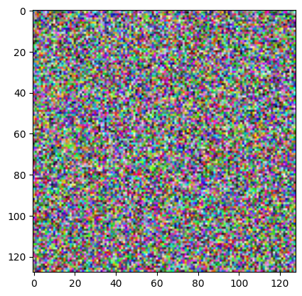

```python
noise = np.random.random((128,128,3))
print(noise.shape)
plt.imshow(noise)
```

# Linear Algebra with Vectors

```python
v1 = np.array([4, 5, 2, 7])
v2 = np.array([2, 1, 3, 3])
```

```python
# Python Lists vs ndarrays
list1 = [4, 5, 2, 7]
list2 = [2, 1, 3, 3]
```

```python
v1 + v2
```

```
array([ 6,  6,  5, 10])
```

```python
list1 + list2
```

```
[4, 5, 2, 7, 2, 1, 3, 3]
```

```python
v1 * v2
```

```
array([ 8,  5,  6, 21])
```

# Broadcasting and Scalars

```python
array_2d = np.array([[1, 2, 3, 4],
                     [5, 6, 7, 8]])
```

```python
array_2d + 10
```

```
array([[11, 12, 13, 14],
       [15, 16, 17, 18]])
```

```python
array_2d * 5
```

```
array([[ 5, 10, 15, 20],
       [25, 30, 35, 40]])
```

# Matrix Multiplication with @ and .matmul()

[figure not shown]

```python
a1 = np.array([[1, 3],
               [0, 1],
               [6, 2],
               [9, 7]])

b1 = np.array([[4, 1, 3],
               [5, 8, 5]])

print(f'{a1.shape}: a has {a1.shape[0]} rows and {a1.shape[1]} columns.')
print(f'{b1.shape}: b has {b1.shape[0]} rows and {b1.shape[1]} columns.')
print('Dimensions of result: (4x2)*(2x3)=(4x3)')
```

```
(4, 2): a has 4 rows and 2 columns.
(2, 3): b has 2 rows and 3 columns.
Dimensions of result: (4x2)*(2x3)=(4x3)
```

**Challenge**: Let's multiply `a1` with `b1`. Looking at the wikipedia example above, work out the values for c12 and c33 on paper. Then use the [`.matmul()`](https://numpy.org/doc/stable/reference/generated/numpy.matmul.html) function or the `@` operator to check your work.

```python
a1 = np.array([[1, 3],
               [0, 1],
               [6, 2],
               [9, 7]])

b1 = np.array([[4, 1, 3],
               [5, 8, 5]])
```

```python
c = np.matmul(a1,b1)
```

```python
c
```

```
array([[19, 25, 18],
       [ 5,  8,  5],
       [34, 22, 28],
       [71, 65, 62]])
```

# Manipulating Images as ndarrays

```python
img = misc.face()
```

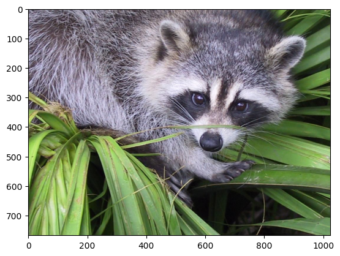

```python
plt.imshow(img)
```

**Challenge**: What is the data type of `img`? Also, what is the shape of `img` and how many dimensions does it have? What is the resolution of the image?

```python
np.shape(img)
```

```
(768, 1024, 3)
```

```python
np.ndim(img)
```

```
3
```

```python
type(img)
```

```
numpy.ndarray
```

**Challenge**: Convert the image to black and white. The values in our `img` range from 0 to 255.

- Divide all the values by 255 to convert them to sRGB, where all the values are between 0 and 1.
- Next, multiply the sRGB array by the `grey_vals` to convert the image to grey scale.
- Finally use Matplotlib's [`.imshow()`](https://matplotlib.org/3.1.1/api/_as_gen/matplotlib.pyplot.imshow.html) together with the colormap parameter set to gray `cmap=gray` to look at the results.

```python
grey_vals = np.array([0.2126, 0.7152, 0.0722])
```

```python
sRGB_array = img / 255
```

```python
grey_vals = np.array([0.2126, 0.7152, 0.0722])
```

```python
img_gray = sRGB_array @ grey_vals
```

```python
img_gray = np.matmul(sRGB_array, grey_vals)
```

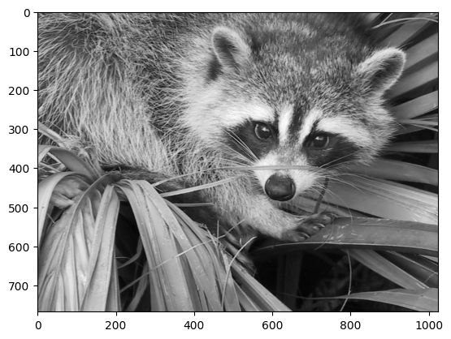

```python
plt.imshow(img_gray, cmap='gray')
```

**Challenge**: Can you manipulate the images by doing some operations on the underlying ndarrays? See if you can change the values in the ndarray so that:

1) You flip the grayscale image upside down

[figure not shown]

2) Rotate the colour image

[figure not shown]

3) Invert (i.e., solarize) the colour image. To do this you need to converting all the pixels to their "opposite" value, so black (0) becomes white (255).

[figure not shown]

#### Challenge Solutions

```python
img = np.flip(img)
```

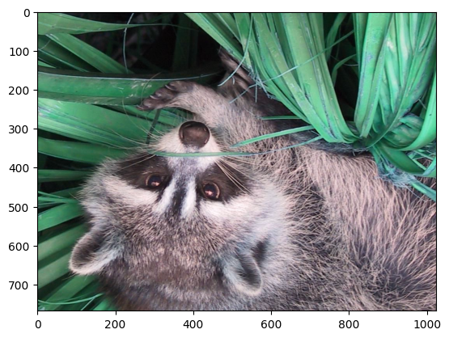

```python
plt.imshow(img)
```

```python
img = np.rot90(img)
```

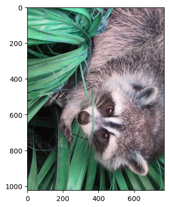

```python
plt.imshow(img)
```

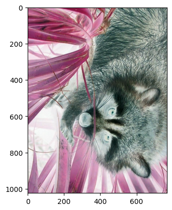

```python
solar_img = 255 - img
plt.imshow(solar_img)
```

# Use your Own Image!

```python
file_name = 'yummy_macarons.jpg'
```

```python
my_img = Image.open(file_name)
img_array = np.array(my_img)
```

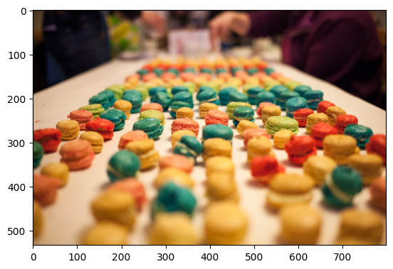

```python
plt.imshow(img_array)
```

```python
np.ndim(img_array)
```

```
3
```

```python
img_array.shape
```

```
(533, 799, 3)
```

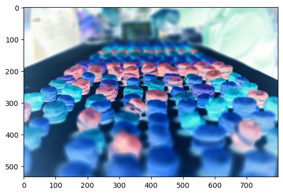

```python
solar_img = 255 - img_array
plt.imshow(solar_img)
```